# Lab2

Molly Carrick

9/13/2020

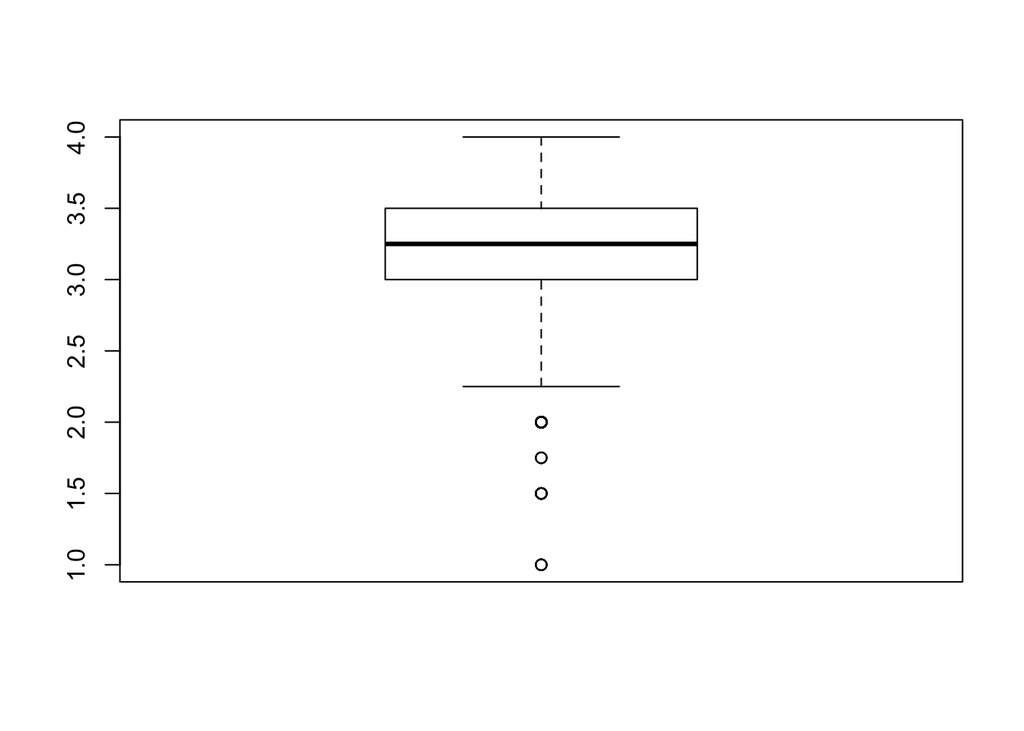

```r
choco<-read.csv("https://raw.githubusercontent.com/xdaiISU/ds202materials/master/hwlabs/data/choco.csv")
boxplot(choco$Rating)
```

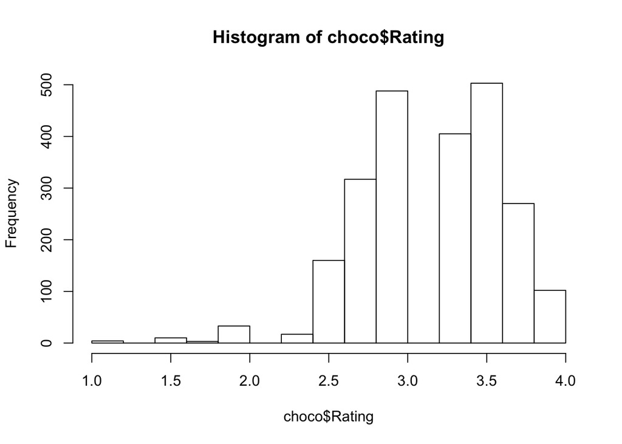

```r
hist(choco$Rating)
```

## Rating Distributions

From the histogram, it is clear that the distribution of ratings is skewed to the left. Based on the boxplot, the median value appears to be around 3.25. There are a few outliers. Based on the boxplot, it appears that there are four outliers, all on the low end of ratings, with the lowest one being a rating of 1.0.

## Ratings Based on Year

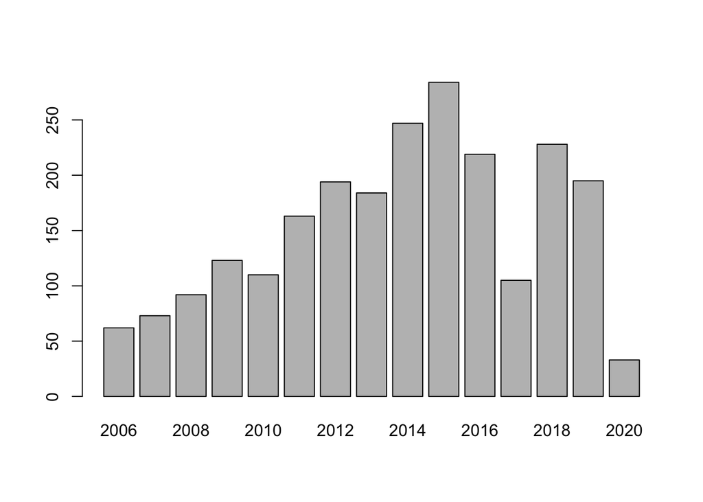

```r
factorDate<-factor(choco$Date)
barplot(table(factorDate))
```

It appears that the number of chocolate bars evaluated each year changes drastically. The year 2015 had the most ratings and the year 2020 had the least ratings, but that is most likely due to the fact that 2020 is not over yet. The range of data is spread over fourteen years and the shape of the barplot is slightly skewered to the left. The number of ratings rose fairly consistently up until 2015, where the was a sudden drop in year 2017. The number of ratings increased greatly in 2018 and then decreased again in 2019 and 2020.

## Cacoa Percentage

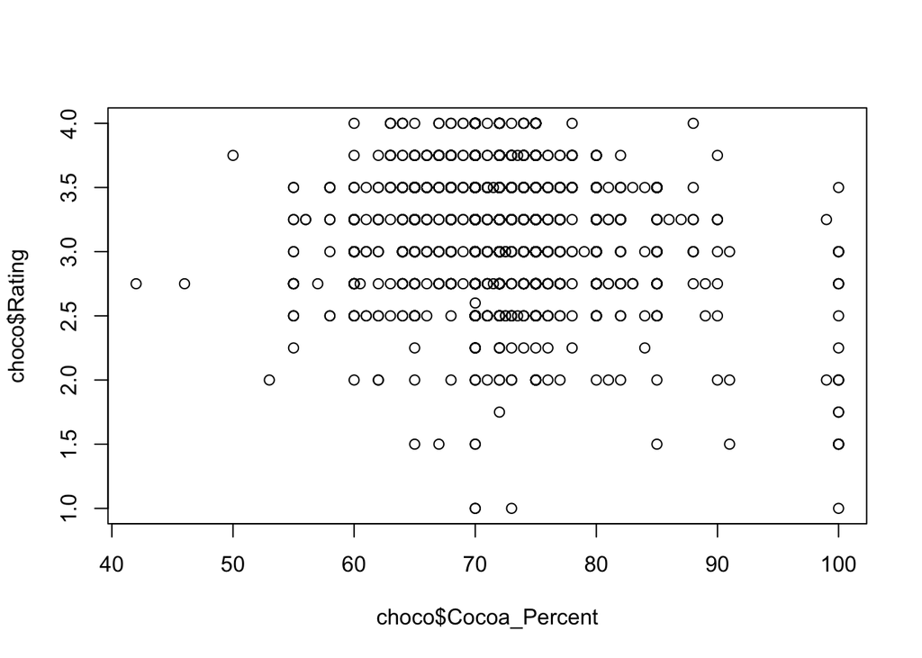

```r
plot(choco$Cocoa_Percent, choco$Rating)
```

```r
cocoaRate<-choco[ , c("Rating", "Cocoa_Percent")]
summary(cocoaRate)
```

```
##      Rating      Cocoa_Percent
##  Min.   :1.000   Min.   : 42.00
##  1st Qu.:3.000   1st Qu.: 70.00
##  Median :3.250   Median : 70.00
##  Mean   :3.184   Mean   : 71.65
##  3rd Qu.:3.500   3rd Qu.: 75.00
##  Max.   :4.000   Max.   :100.00
```

## Characteristics of Chocolate Bars

```r
head(sort(table(choco$Characteristics1), decreasing=TRUE))
```

```
##
##  creamy   sandy intense   nutty   fatty   sweet
##     162     134      82      78      76      74
```

```r
head(sort(table(choco$Characteristics2), decreasing=TRUE))
```

```
##
##  sweet  nutty earthy  cocoa roasty floral
##    120     86     75     69     65     60
```

```r
head(sort(table(choco$Characteristics3), decreasing=TRUE))
```

```
##
##  cocoa  nutty roasty   sour earthy  sweet
##     96     71     70     65     50     48
```

```r
head(sort(table(choco$Characteristics4), decreasing=TRUE))
```

```
##
##  cocoa roasty   sour   rich earthy  nutty
##     16     16     13     11     10      9
```

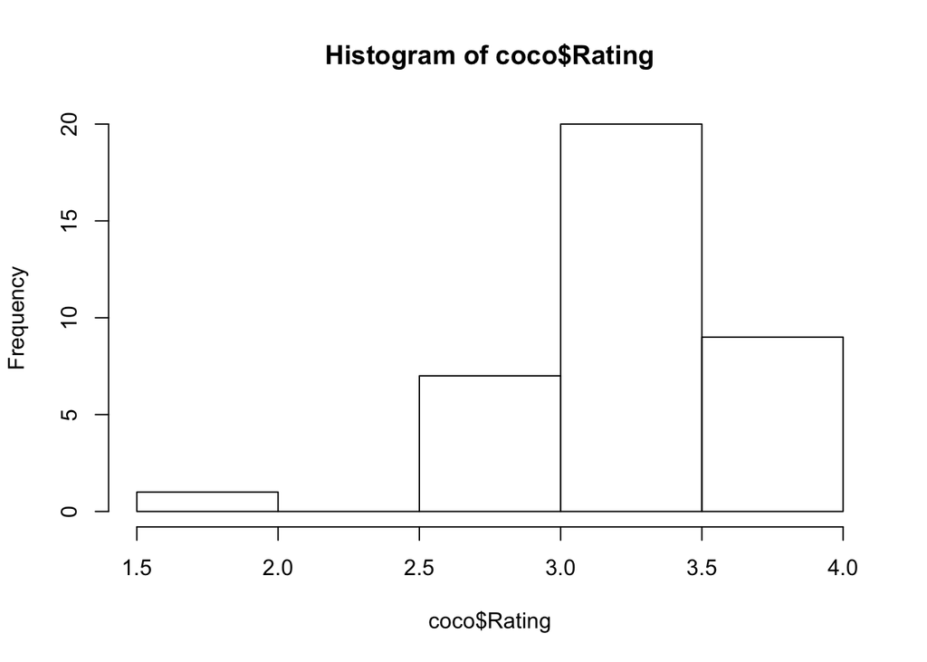

```r
charact<-choco[ , c("Characteristics1", "Characteristics2", "Characteristics3", "Characteristics4")]
coco<-choco[charact=="cocoa", ]
hist(coco$Rating)
```

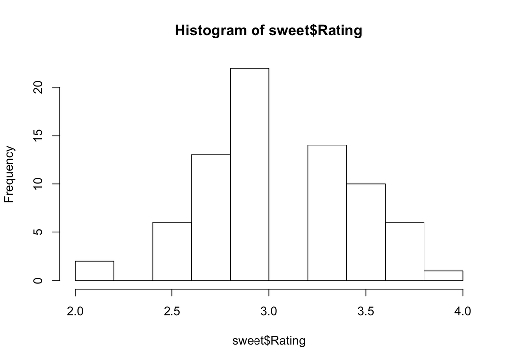

```r
sweet<-choco[charact=="sweet", ]
hist(sweet$Rating)
```

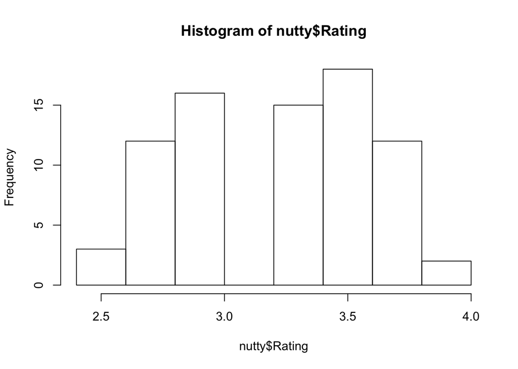

```r
nutty<-choco[charact=="nutty", ]
hist(nutty$Rating)
```

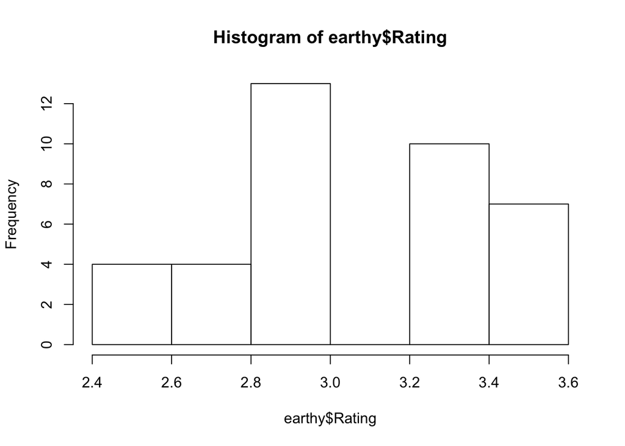

```r
earthy<-choco[charact=="earthy", ]
hist(earthy$Rating)
```

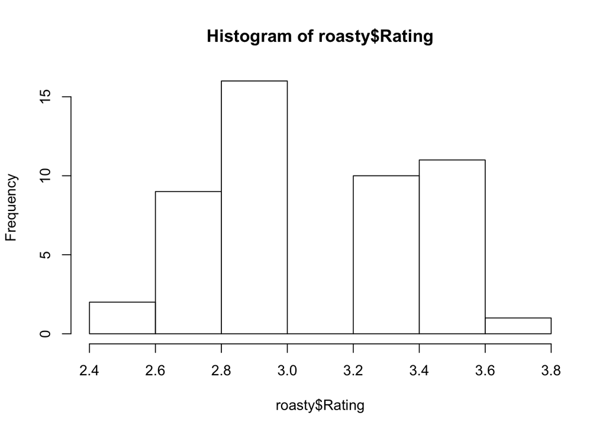

```r
roasty<-choco[charact=="roasty", ]
hist(roasty$Rating)
```

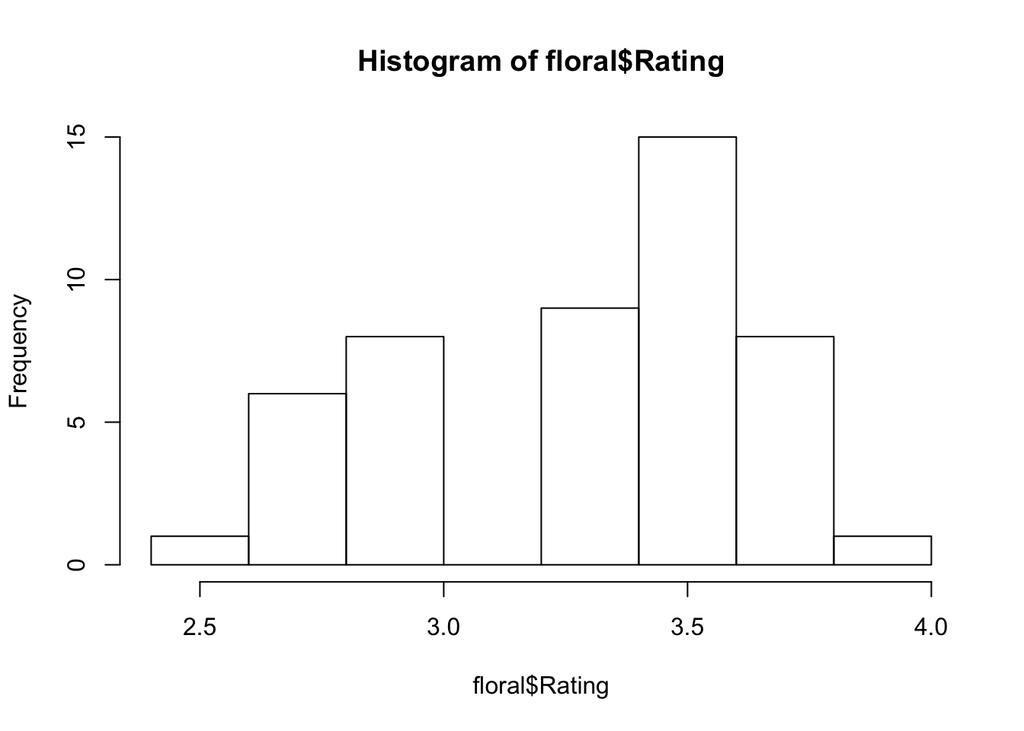

```r
floral<-choco[charact=="floral", ]
hist(floral$Rating)
```

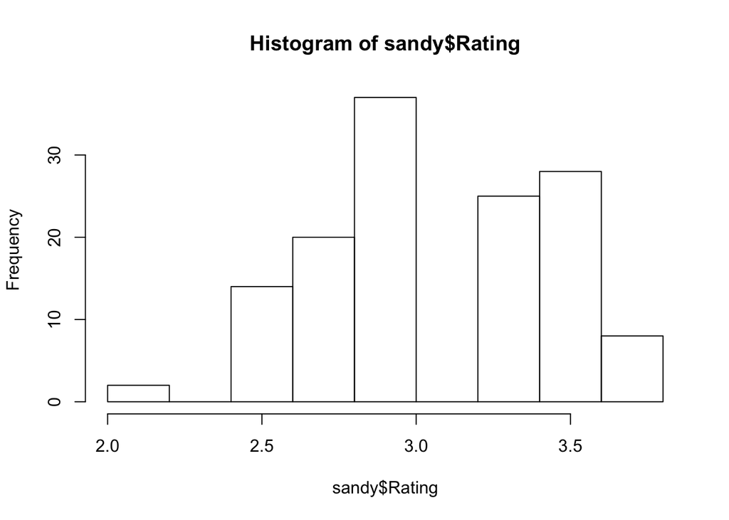

```r
sandy<-choco[charact=="sandy", ]
hist(sandy$Rating)
```

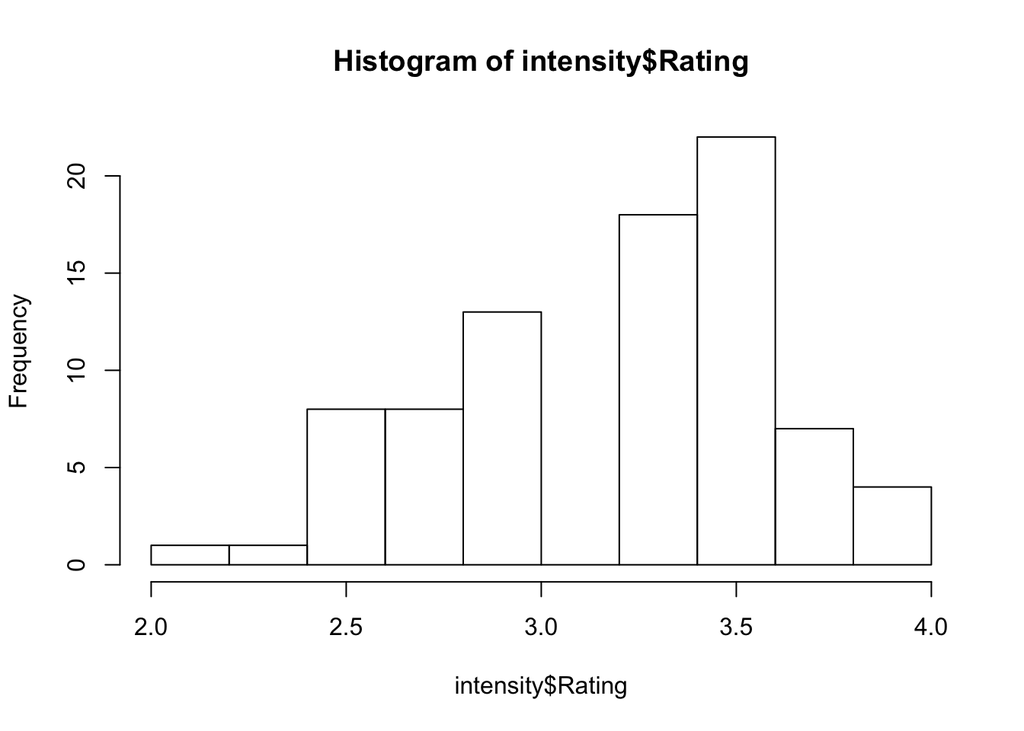

```r
intensity<-choco[charact=="intense", ]
hist(intensity$Rating)
```

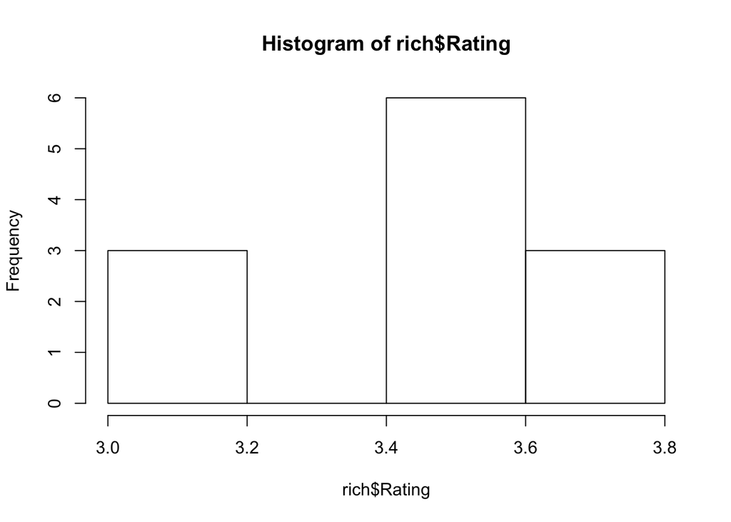

```r
rich<-choco[charact=="rich", ]
hist(rich$Rating)
```

```r
mean(coco$Rating, na.rm=TRUE)
```

```
## [1] 3.371622
```

```r
mean(sweet$Rating, na.rm=TRUE)
```

```
## [1] 3.077703
```

```r
mean(nutty$Rating, na.rm=TRUE)
```

```
## [1] 3.246795
```

```r
mean(earthy$Rating, na.rm=TRUE)
```

```
## [1] 3.078947
```

```r
mean(roasty$Rating, na.rm=TRUE)
```

```
## [1] 3.112245
```

```r
mean(floral$Rating, na.rm=TRUE)
```

```
## [1] 3.307292
```

```r
mean(sandy$Rating, na.rm=TRUE)
```

```
## [1] 3.091418
```

```r
mean(intensity$Rating, na.rm=TRUE)
```

```
## [1] 3.207317
```

```r
mean(rich$Rating, na.rm=TRUE)
```

```
## [1] 3.4375
```